# Analysis of Breast Tumor Tissue Biopsies Using PCA

Agustín Castro

26 de agosto de 2024

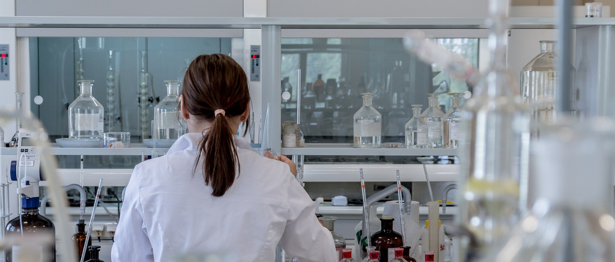

# Introduction

**Data consulting & education**  
Pills_R. Training Material

[website] https://agustincastro.es

[RPubs] https://rpubs.com/acastro

[GitHub-R] https://github.com/acastromartinez/GITHUB---R

### About the Technique

In this practice, we will work with the **Principal Component Analysis (PCA) technique** to reduce dimensionality in datasets with a large number of variables. PCA simplifies the analysis and enhances the visualization and interpretation of results by transforming the original variables into a new set of principal components. These components retain the maximum amount of information possible using fewer dimensions. The first principal component explains the most variance in the data, while each subsequent component captures the maximum remaining variance without overlapping the information already explained by the previous components.

**PCA is particularly valuable for large datasets, as it allows for significant simplification of the analysis and effective visualization without sacrificing relevant information**.

### About the Dataset

We will use the dataset **biopsy** from the **MASS** package, one of the most popular and widely used in statistical analysis. It was developed by the group of Venables and Ripley and accompanies the book **Modern Applied Statistics with S**.

The dataset **biopsy** contains information for the **classification of breast tumors** as **benign** or **malignant** based on characteristics obtained from fine needle aspiration biopsy images of breast masses. The data includes both quantitative features of the cells and the final tumor classification. It is a small, manageable dataset that offers a variety of features for applying multiple modeling techniques and is ideal for teaching and experimenting with data analysis and machine learning. Additionally, it is well-documented and supported in the MASS package for R.

### Packages

```r
library(MASS)
# install.packages("MASS") if necessary

library(tidyverse)
library(ggplot2)
library(corrplot) #*
library(GGally) #*
library(factoextra) #*
library(gridExtra) #*

#* ver anexo
```

# Load dataset information

Data obtained from the **University of Wisconsin Hospitals, Madison (Dr. Wolberg)**. It is based on the evaluation of 699 breast tumor biopsies. Each of the nine attributes V1-V9 is scored on a scale from 1 to 10. The two-level classification, **benign** and **malignant**, is also known.

```r
data(biopsy)
citation("MASS") # how to cite the dataset
```

```
##
##   Venables, W. N. & Ripley, B. D. (2002) Modern Applied Statistics with
##   S. Fourth Edition. Springer, New York. ISBN 0-387-95457-0
##
## A BibTeX entry for LaTeX users is
##
##   @Book{,
##     title = {Modern Applied Statistics with S},
##     author = {W. N. Venables and B. D. Ripley},
##     publisher = {Springer},
##     edition = {Fourth},
##     address = {New York},
##     year = {2002},
##     note = {ISBN 0-387-95457-0},
##     url = {https://www.stats.ox.ac.uk/pub/MASS4/},
##   }
```